# PhD Chapter 3 - RelativeSize

```
## [1] "Time point  2"
```

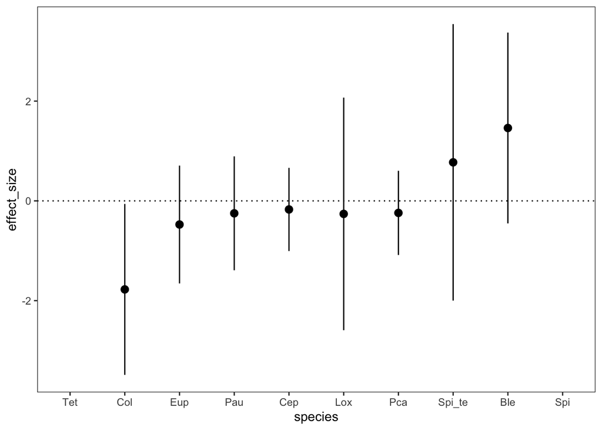

```
## [1] "Time point  3"
```

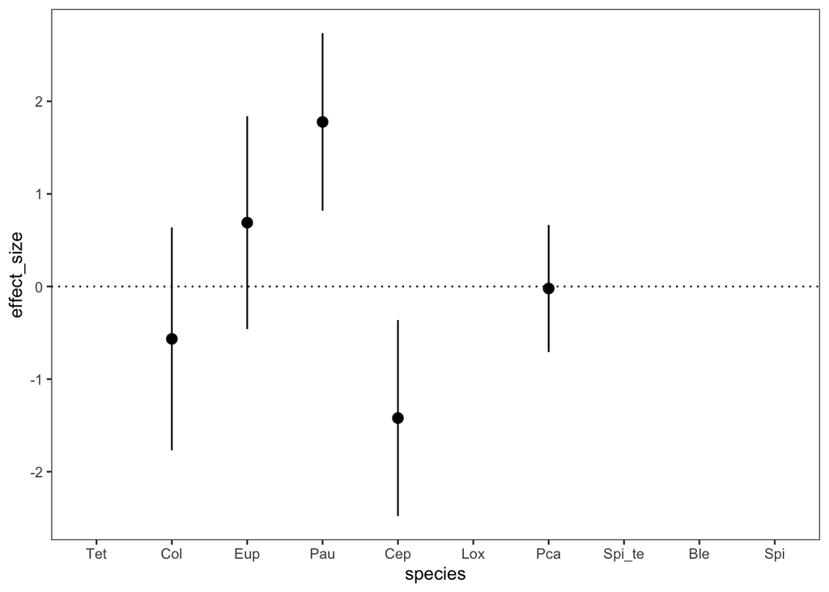

```
## [1] "Time point  4"
```

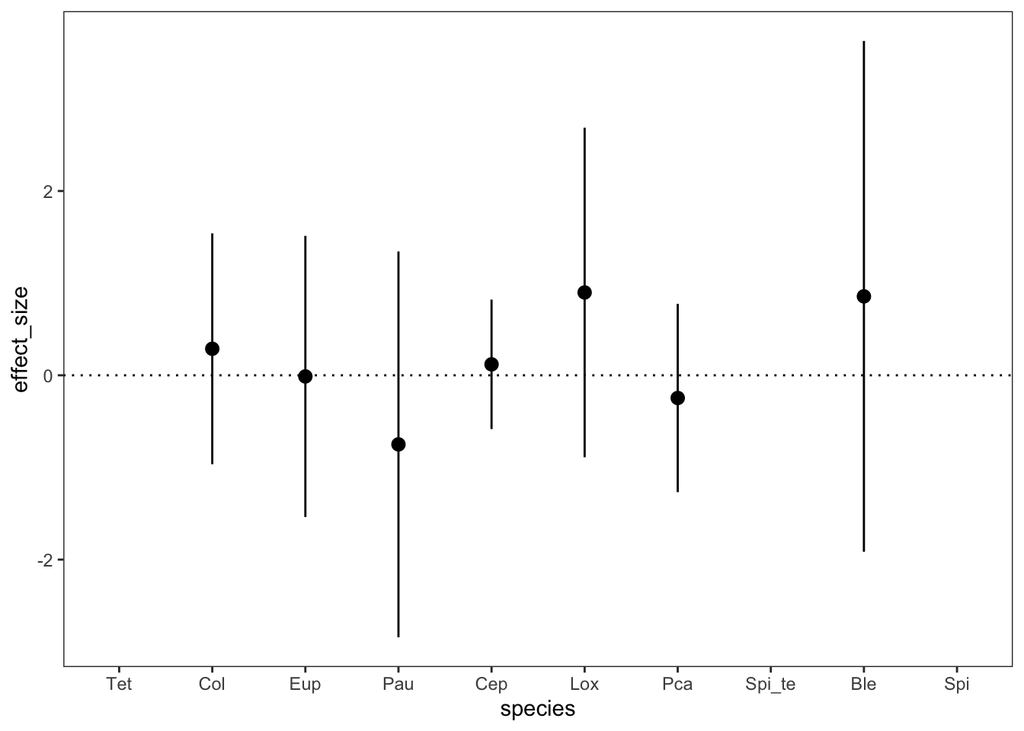

```r
for(time_point_i in 2:4){

    print(paste("Time point ", time_point_i))

    p = ds_species_effect_sizes_LRR %>%
      filter(time_point == time_point_i,
             species != "Eug",
             ecosystem_size_ml == ecosystem_size_i,
             trophic_type == "heterotrophic",
             connection == "connected",
             disturbance_percentage == disturbance_percentage_selected) %>%
      ggplot(aes(x = species,
                 y = effect_size)) +
      geom_pointrange(aes(ymin = lower_95_CI, ymax = upper_95_CI)) +
      geom_hline(yintercept = 0, linetype = "dotted") +
      theme_bw() +
      theme(panel.grid.major = element_blank(),
            panel.grid.minor = element_blank(),
            legend.position = legend_position,
            legend.key.width = unit(legend_width_cm, "cm"))

    print(p)

  }
```

###### 45.00 ml

```r
ecosystem_size_i = 45.00
```

```r
"Connected"
```

```
## [1] "Connected"
```

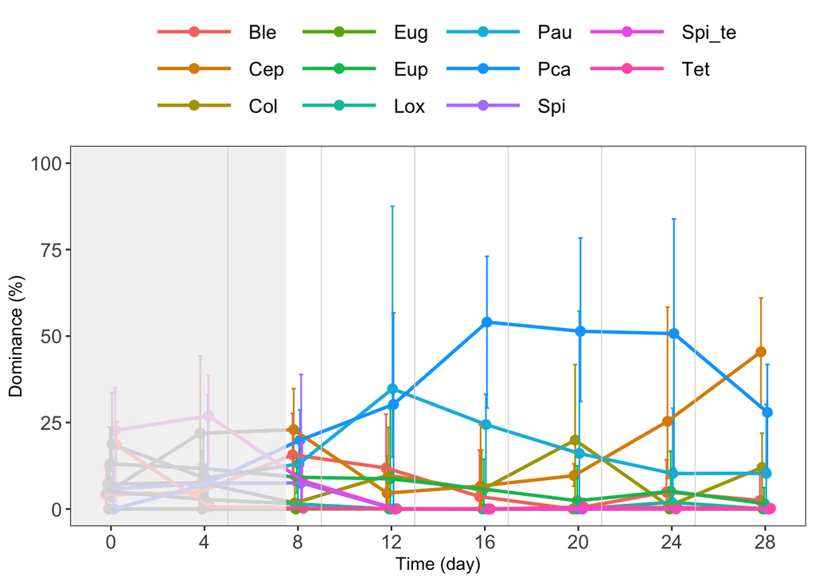

```r
print_dominance(ecosystem_size_i,
                "connected",
                disturbance_percentage_selected)
```

```r
"Unconnected"
```

```
## [1] "Unconnected"
```

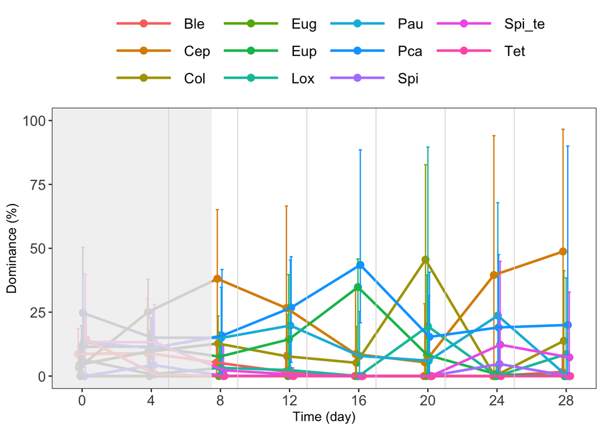

```r
print_dominance(ecosystem_size_i,
                "unconnected",
                disturbance_percentage_selected)
```

**Click to view the effect size (connected vs unconnected) with Hedge’s d**

```r
"Hedge's d"
```

```
## [1] "Hedge's d"
```

```r
for(time_point_i in 2:4){

    print(paste("Time point ", time_point_i))

    p = ds_species_effect_sizes_d %>%
      filter(connection == "connected",
             time_point == time_point_i,
             species != "Eug") %>%
      ggplot(aes(x = species,
                 y = effect_size)) +
      geom_pointrange(aes(ymin = lower_95_CI, ymax = upper_95_CI)) +
      geom_hline(yintercept = 0, linetype = "dotted") +
      theme_bw() +
      theme(panel.grid.major = element_blank(),
            panel.grid.minor = element_blank(),
            legend.position = legend_position,
            legend.key.width = unit(legend_width_cm, "cm"))

    print(p)

  }
```

```
## [1] "Time point  2"
```

```
## [1] "Time point  3"
```

```
## [1] "Time point  4"
```

**Click to view the effect size (connected vs unconnected) with log response ratio (LRR)**

```r
"LRR"
```

```
## [1] "LRR"
```

```
## [1] "Time point  2"
```

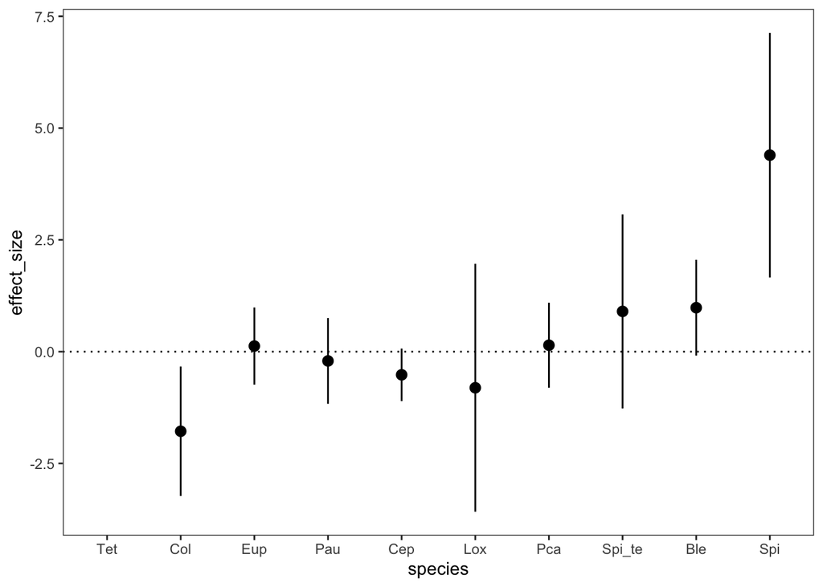

```
## [1] "Time point  3"
```

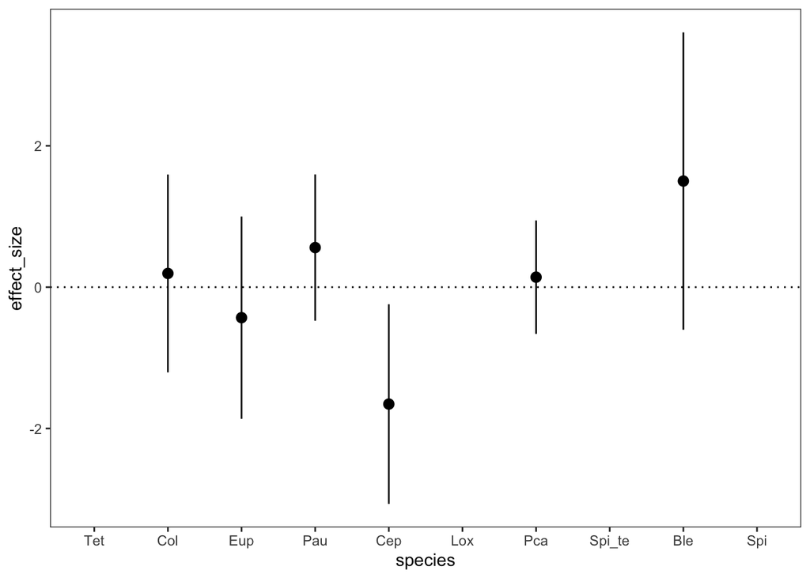

```
## [1] "Time point  4"
```

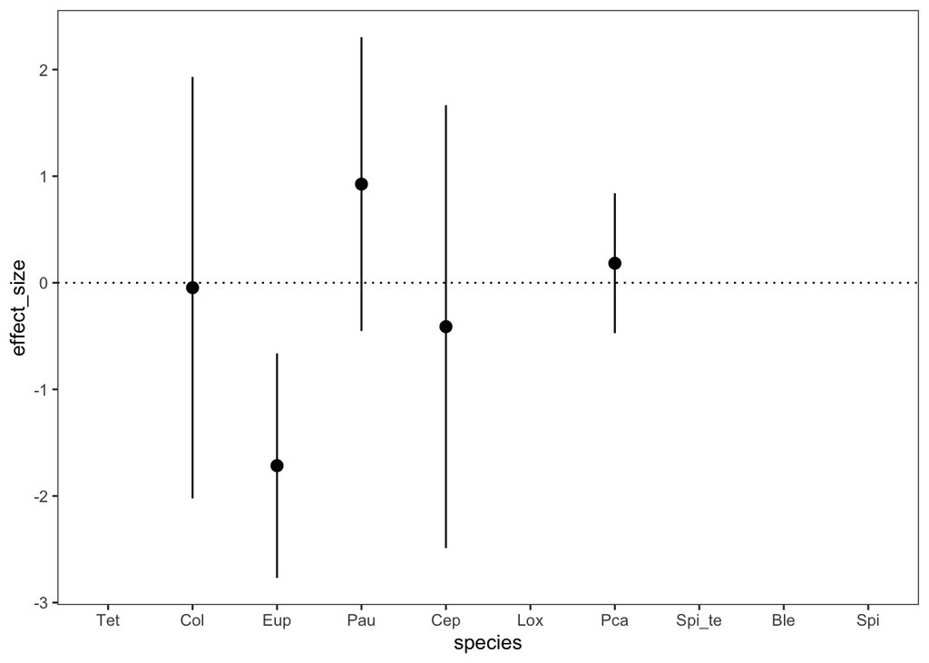

```r
for(time_point_i in 2:4){

    print(paste("Time point ", time_point_i))

    p = ds_species_effect_sizes_LRR %>%
      filter(time_point == time_point_i,
             species != "Eug",
             ecosystem_size_ml == ecosystem_size_i,
             trophic_type == "heterotrophic",
             connection == "connected",
             disturbance_percentage == disturbance_percentage_selected) %>%
      ggplot(aes(x = species,
                 y = effect_size)) +
      geom_pointrange(aes(ymin = lower_95_CI, ymax = upper_95_CI)) +
      geom_hline(yintercept = 0, linetype = "dotted") +
      theme_bw() +
      theme(panel.grid.major = element_blank(),
            panel.grid.minor = element_blank(),
            legend.position = legend_position,
            legend.key.width = unit(legend_width_cm, "cm"))

    print(p)

  }
```

##### Disturbance relative to size

```r
disturbance_percentage_selected = "decreasing_with_size"
```

###### 6.43 ml

```r
ecosystem_size_i = 6.43
```

```r
"Connected"
```

```
## [1] "Connected"
```

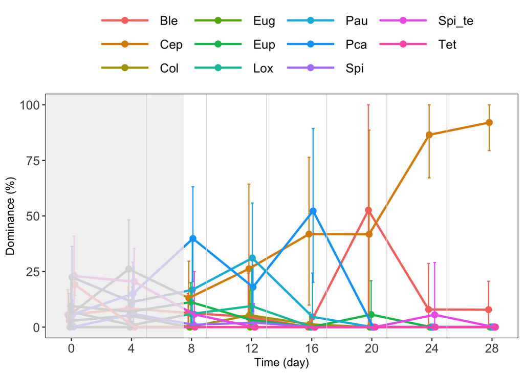

```r
print_dominance(ecosystem_size_i,
                "connected",
                disturbance_percentage_selected)
```

```r
"Unconnected"
```

```
## [1] "Unconnected"
```

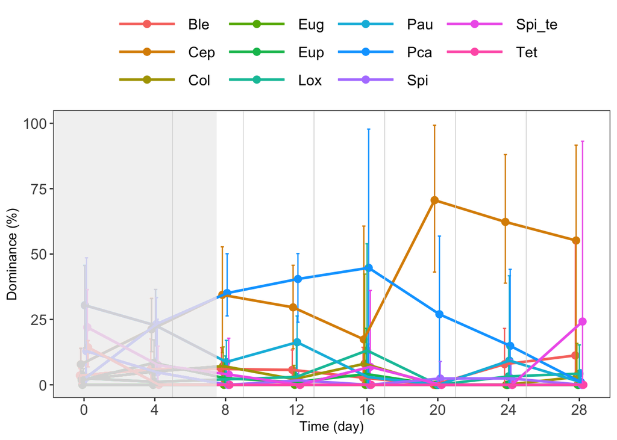

```r
print_dominance(ecosystem_size_i,
                "unconnected",
                disturbance_percentage_selected)
```

**Click to view the effect size (connected vs unconnected) with Hedge’s d**

```r
"Hedge's d"
```

```
## [1] "Hedge's d"
```

```r
for(time_point_i in 2:4){

    print(paste("Time point ", time_point_i))

    p = ds_species_effect_sizes_d %>%
      filter(connection == "connected",
             time_point == time_point_i,
             species != "Eug") %>%
      ggplot(aes(x = species,
                 y = effect_size)) +
      geom_pointrange(aes(ymin = lower_95_CI, ymax = upper_95_CI)) +
      geom_hline(yintercept = 0, linetype = "dotted") +
      theme_bw() +
      theme(panel.grid.major = element_blank(),
            panel.grid.minor = element_blank(),
            legend.position = legend_position,
            legend.key.width = unit(legend_width_cm, "cm"))

    print(p)

  }
```

```
## [1] "Time point  2"
```

```
## [1] "Time point  3"
```

```
## [1] "Time point  4"
```

**Click to view the effect size (connected vs unconnected) with log response ratio (LRR)**

```r
"LRR"
```

```
## [1] "LRR"
```

```
## [1] "Time point  2"
```

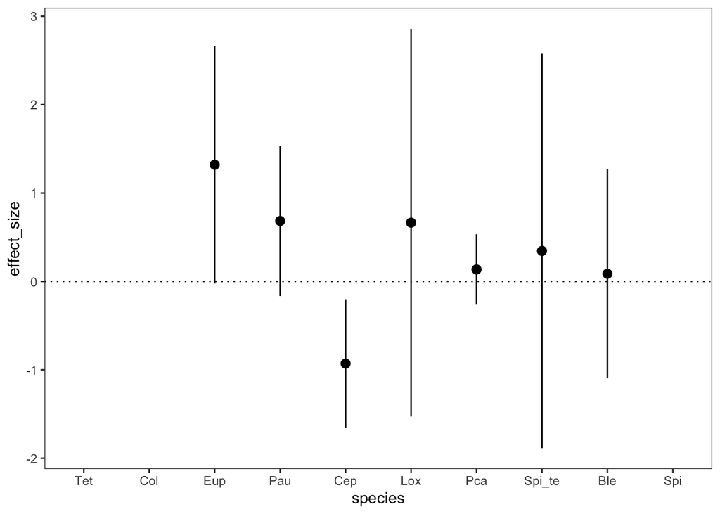

```
## [1] "Time point  3"
```

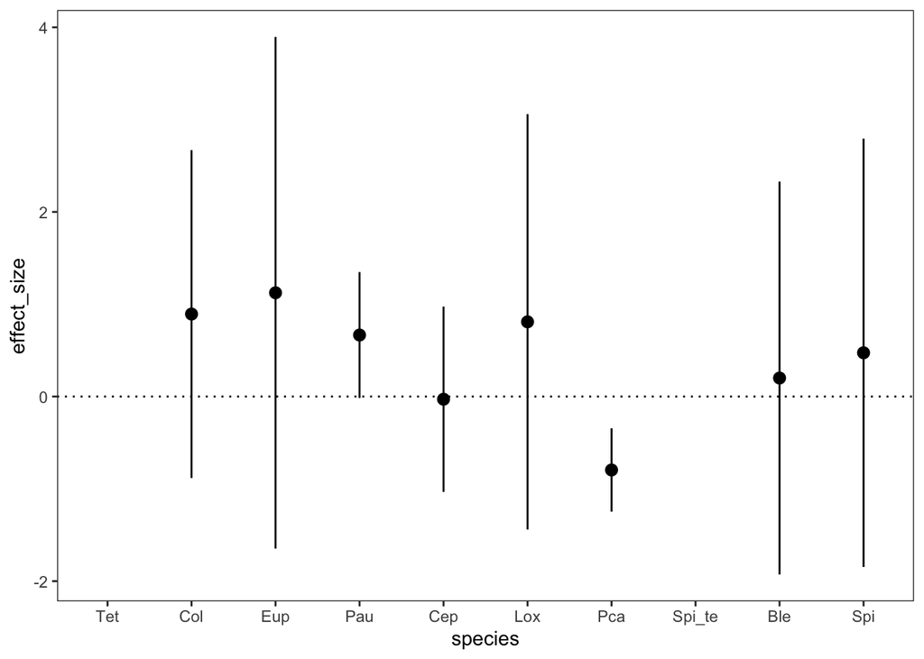

```
## [1] "Time point  4"
```

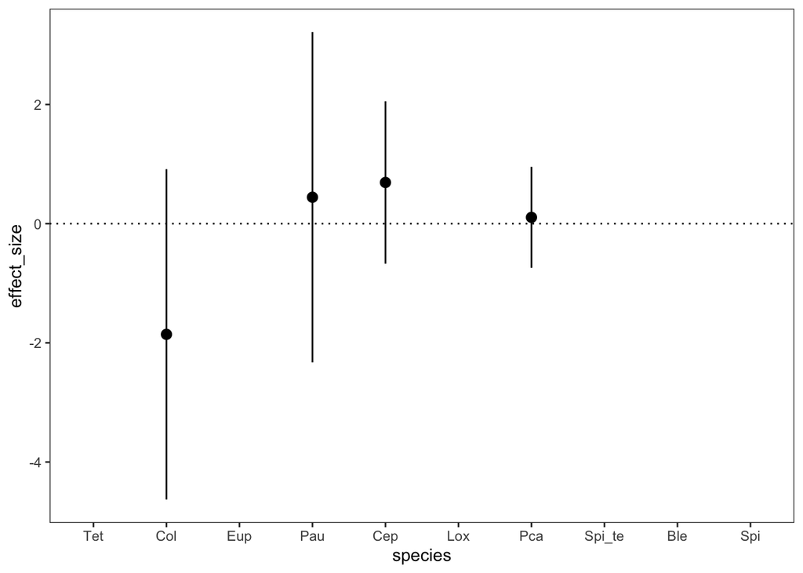

```r
for(time_point_i in 2:4){

    print(paste("Time point ", time_point_i))

    p = ds_species_effect_sizes_LRR %>%
      filter(time_point == time_point_i,
             species != "Eug",
             ecosystem_size_ml == ecosystem_size_i,
             trophic_type == "heterotrophic",
             connection == "connected",
             disturbance_percentage == disturbance_percentage_selected) %>%
      ggplot(aes(x = species,
                 y = effect_size)) +
      geom_pointrange(aes(ymin = lower_95_CI, ymax = upper_95_CI)) +
      geom_hline(yintercept = 0, linetype = "dotted") +
      theme_bw() +
      theme(panel.grid.major = element_blank(),
            panel.grid.minor = element_blank(),
            legend.position = legend_position,
            legend.key.width = unit(legend_width_cm, "cm"))

    print(p)

  }
```

###### 9.00 ml

```r
ecosystem_size_i = 9.00
```

```r
"Connected"
```

```
## [1] "Connected"
```

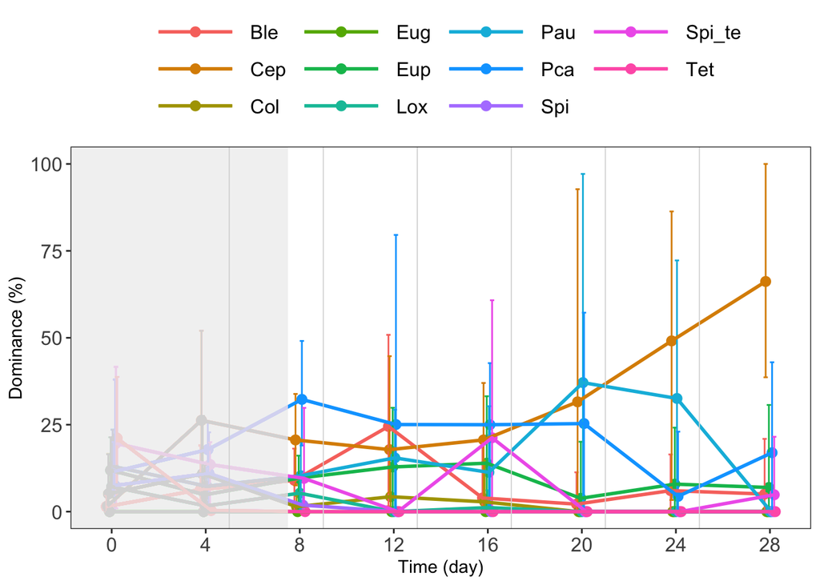

```r
print_dominance(ecosystem_size_i,
                "connected",
                disturbance_percentage_selected)
```

```r
"Unconnected"
```

```
## [1] "Unconnected"
```

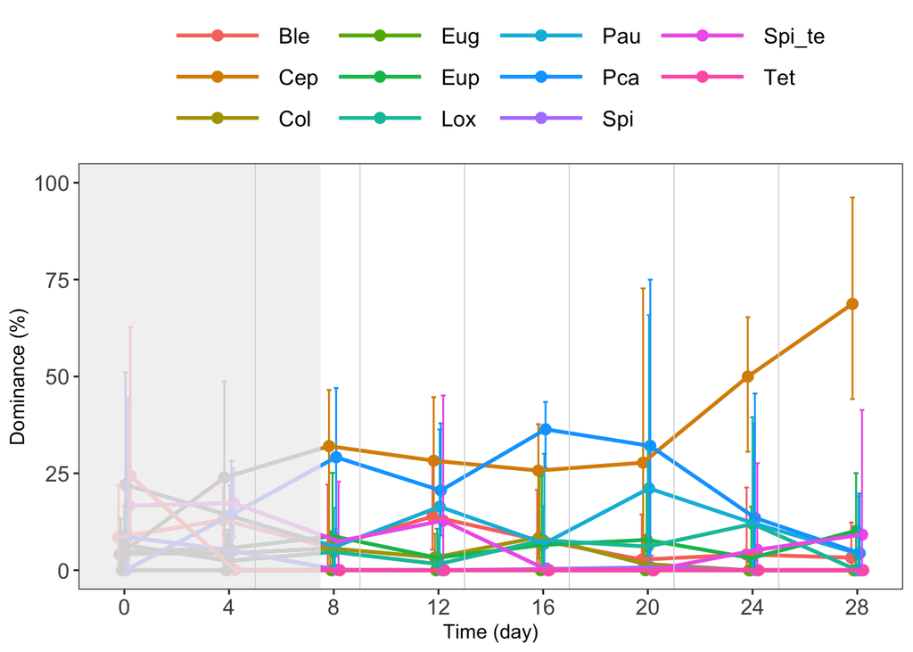

```r
print_dominance(ecosystem_size_i,
                "unconnected",
                disturbance_percentage_selected)
```

**Click to view the effect size (connected vs unconnected) with Hedge’s d**

```r
"Hedge's d"
```

```
## [1] "Hedge's d"
```

```r
for(time_point_i in 2:4){

    print(paste("Time point ", time_point_i))

    p = ds_species_effect_sizes_d %>%
      filter(connection == "connected",
             time_point == time_point_i,
             species != "Eug") %>%
      ggplot(aes(x = species,
                 y = effect_size)) +
      geom_pointrange(aes(ymin = lower_95_CI, ymax = upper_95_CI)) +
      geom_hline(yintercept = 0, linetype = "dotted") +
      theme_bw() +
      theme(panel.grid.major = element_blank(),
            panel.grid.minor = element_blank(),
            legend.position = legend_position,
            legend.key.width = unit(legend_width_cm, "cm"))

    print(p)

  }
```

```
## [1] "Time point  2"
```

```
## [1] "Time point  3"
```

```
## [1] "Time point  4"
```

**Click to view the effect size (connected vs unconnected) with log response ratio (LRR)**

```r
"LRR"
```

```
## [1] "LRR"
```

```
## [1] "Time point  2"
```

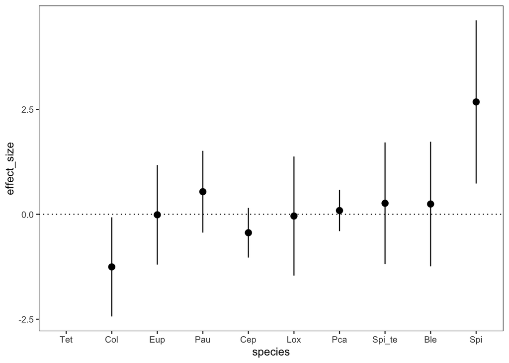

```
## [1] "Time point  3"
```

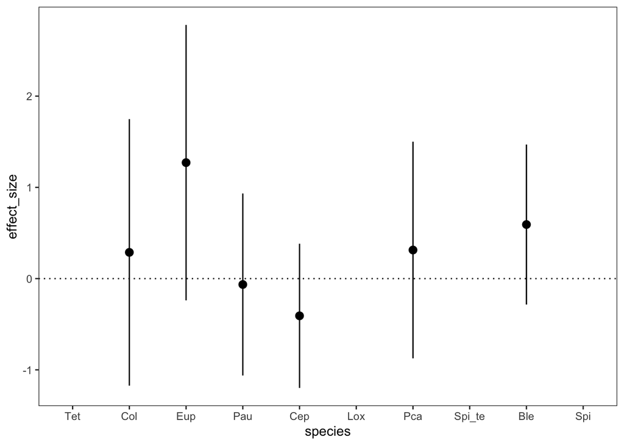

```
## [1] "Time point  4"
```

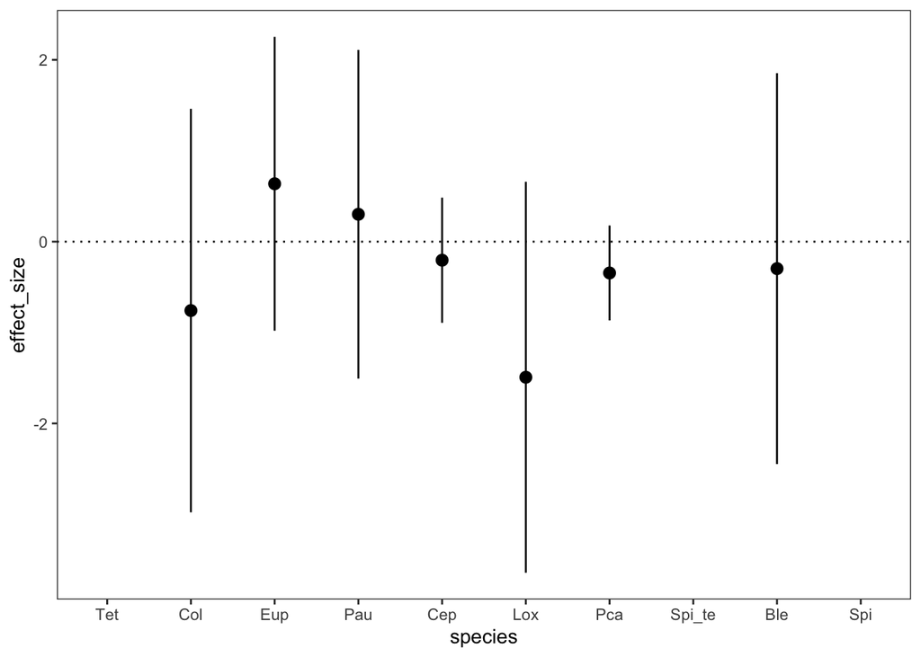

```r
for(time_point_i in 2:4){

    print(paste("Time point ", time_point_i))

    p = ds_species_effect_sizes_LRR %>%
      filter(time_point == time_point_i,
             species != "Eug",
             ecosystem_size_ml == ecosystem_size_i,
             trophic_type == "heterotrophic",
             connection == "connected",
             disturbance_percentage == disturbance_percentage_selected) %>%
      ggplot(aes(x = species,
                 y = effect_size)) +
      geom_pointrange(aes(ymin = lower_95_CI, ymax = upper_95_CI)) +
      geom_hline(yintercept = 0, linetype = "dotted") +
      theme_bw() +
      theme(panel.grid.major = element_blank(),
            panel.grid.minor = element_blank(),
            legend.position = legend_position,
            legend.key.width = unit(legend_width_cm, "cm"))

    print(p)

  }
```

###### 15.00 ml

```r
ecosystem_size_i = 15.00
```

```r
"Connected"
```

```
## [1] "Connected"
```

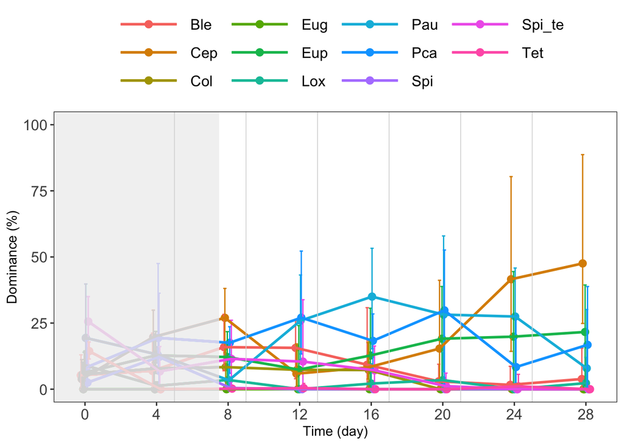

```r
print_dominance(ecosystem_size_i,
                "connected",
                disturbance_percentage_selected)
```

```r
"Unconnected"
```

```
## [1] "Unconnected"
```

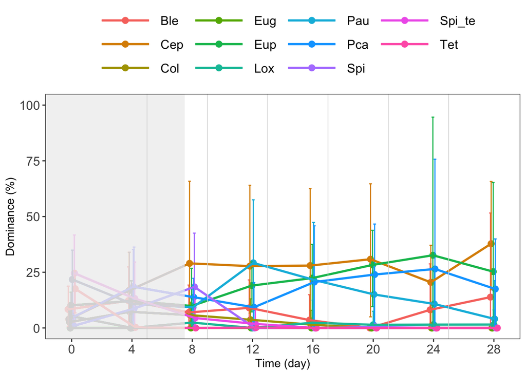

```r
print_dominance(ecosystem_size_i,
                "unconnected",
                disturbance_percentage_selected)
```

**Click to view the effect size (connected vs unconnected) with Hedge’s d**

```r
"Hedge's d"
```

```
## [1] "Hedge's d"
```

```r
for(time_point_i in 2:4){

    print(paste("Time point ", time_point_i))

    p = ds_species_effect_sizes_d %>%
      filter(connection == "connected",
             time_point == time_point_i,
             species != "Eug") %>%
      ggplot(aes(x = species,
                 y = effect_size)) +
      geom_pointrange(aes(ymin = lower_95_CI, ymax = upper_95_CI)) +
      geom_hline(yintercept = 0, linetype = "dotted") +
      theme_bw() +
      theme(panel.grid.major = element_blank(),
            panel.grid.minor = element_blank(),
            legend.position = legend_position,
            legend.key.width = unit(legend_width_cm, "cm"))

    print(p)

  }
```

```
## [1] "Time point  2"
```

```
## [1] "Time point  3"
```

```
## [1] "Time point  4"
```

**Click to view the effect size (connected vs unconnected) with log response ratio (LRR)**

```r
"LRR"
```

```
## [1] "LRR"
```

```
## [1] "Time point  2"
```

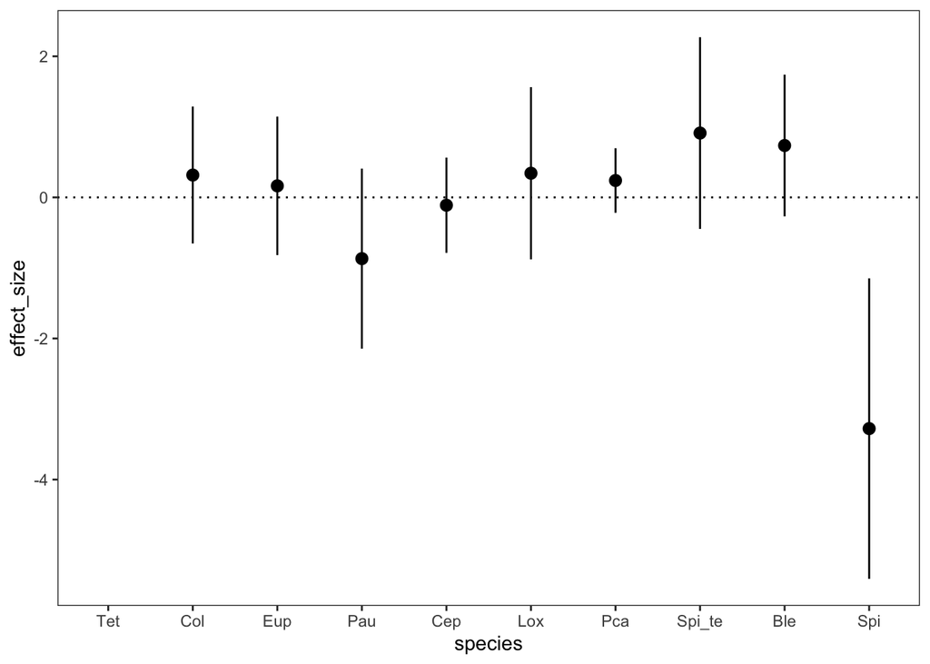

```
## [1] "Time point  3"
```

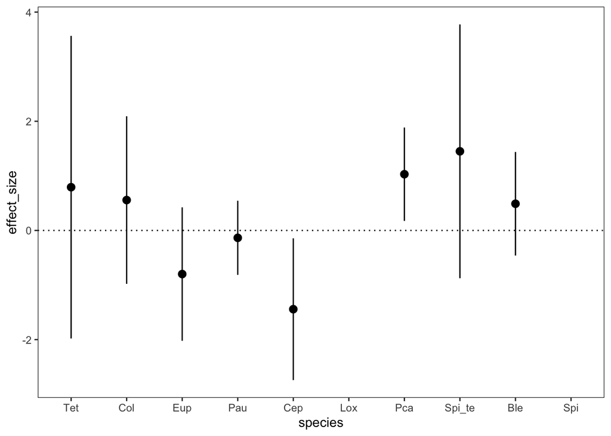

```
## [1] "Time point  4"
```

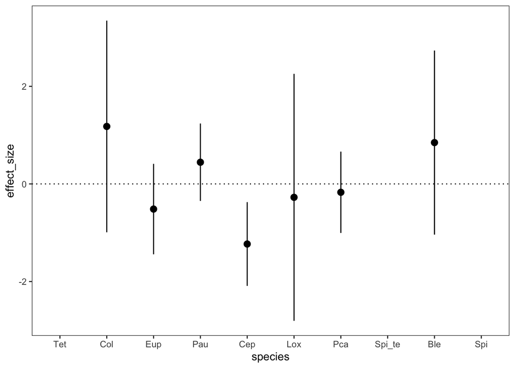

```r
for(time_point_i in 2:4){

    print(paste("Time point ", time_point_i))

    p = ds_species_effect_sizes_LRR %>%
      filter(time_point == time_point_i,
             species != "Eug",
             ecosystem_size_ml == ecosystem_size_i,
             trophic_type == "heterotrophic",
             connection == "connected",
             disturbance_percentage == disturbance_percentage_selected) %>%
      ggplot(aes(x = species,
                 y = effect_size)) +
      geom_pointrange(aes(ymin = lower_95_CI, ymax = upper_95_CI)) +
      geom_hline(yintercept = 0, linetype = "dotted") +
      theme_bw() +
      theme(panel.grid.major = element_blank(),
            panel.grid.minor = element_blank(),
            legend.position = legend_position,
            legend.key.width = unit(legend_width_cm, "cm"))

    print(p)

  }
```

###### 45.00 ml

```r
ecosystem_size_i = 45.00
```

```r
"Connected"
```

```
## [1] "Connected"
```

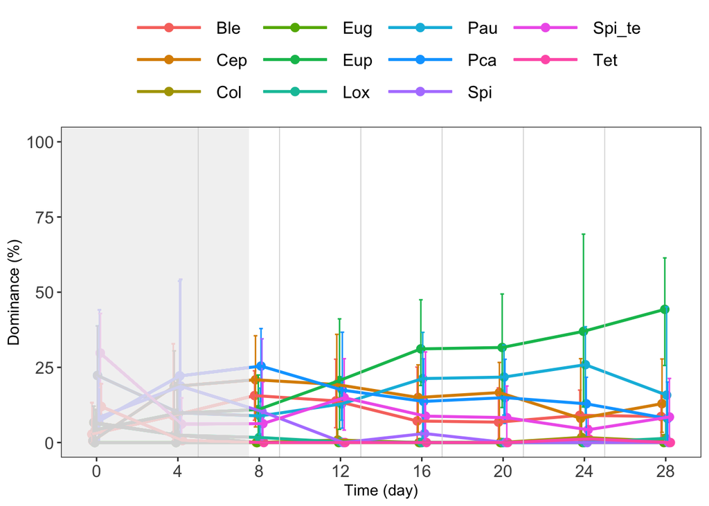

```r
print_dominance(ecosystem_size_i,
                "connected",
                disturbance_percentage_selected)
```

```r
"Unconnected"
```

```
## [1] "Unconnected"
```

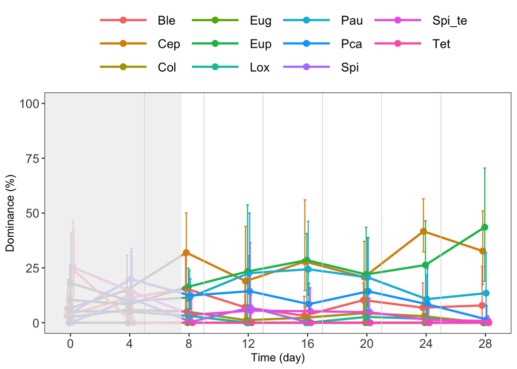

```r
print_dominance(ecosystem_size_i,
                "unconnected",
                disturbance_percentage_selected)
```

**Click to view the effect size (connected vs unconnected) with Hedge’s d**

```r
"Hedge's d"
```

```
## [1] "Hedge's d"
```

```r
for(time_point_i in 2:4){

    print(paste("Time point ", time_point_i))

    p = ds_species_effect_sizes_d %>%
      filter(connection == "connected",
             time_point == time_point_i,
             species != "Eug") %>%
      ggplot(aes(x = species,
                 y = effect_size)) +
      geom_pointrange(aes(ymin = lower_95_CI, ymax = upper_95_CI)) +
      geom_hline(yintercept = 0, linetype = "dotted") +
      theme_bw() +
      theme(panel.grid.major = element_blank(),
            panel.grid.minor = element_blank(),
            legend.position = legend_position,
            legend.key.width = unit(legend_width_cm, "cm"))

    print(p)

  }
```

```
## [1] "Time point  2"
```

```
## [1] "Time point  3"
```

```
## [1] "Time point  4"
```

**Click to view the effect size (connected vs unconnected) with log response ratio (LRR)**

```r
"LRR"
```

```
## [1] "LRR"
```

```
## [1] "Time point  2"
```

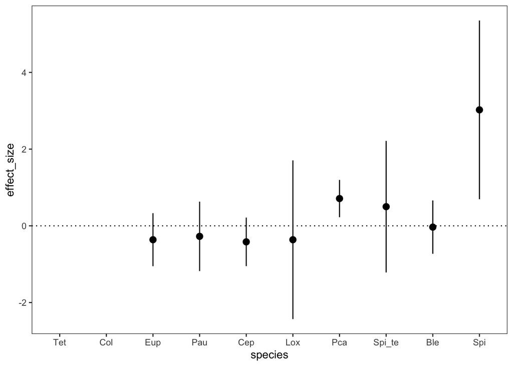

```
## [1] "Time point  3"
```

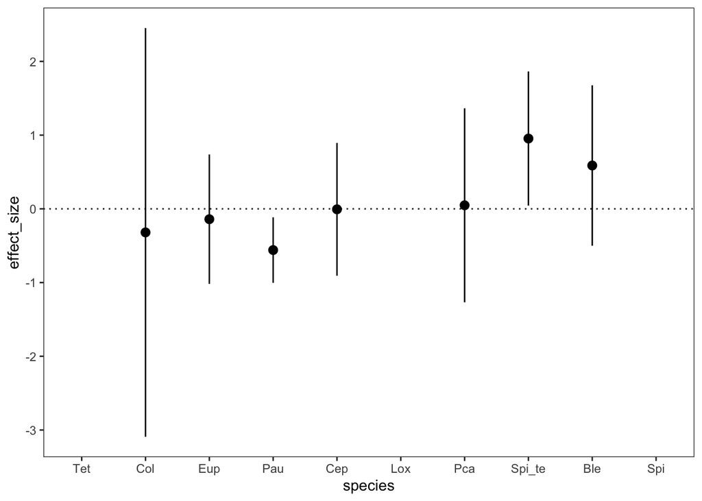

```
## [1] "Time point  4"
```

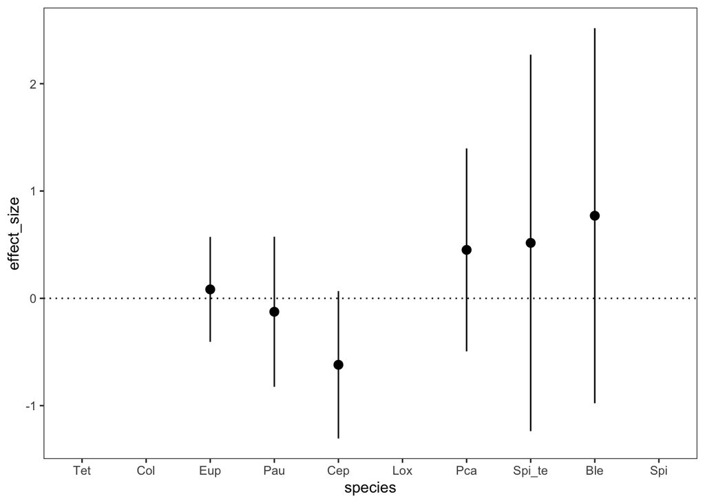

```r
for(time_point_i in 2:4){

    print(paste("Time point ", time_point_i))

    p = ds_species_effect_sizes_LRR %>%
      filter(time_point == time_point_i,
             species != "Eug",
             ecosystem_size_ml == ecosystem_size_i,
             trophic_type == "heterotrophic",
             connection == "connected",
             disturbance_percentage == disturbance_percentage_selected) %>%
      ggplot(aes(x = species,
                 y = effect_size)) +
      geom_pointrange(aes(ymin = lower_95_CI, ymax = upper_95_CI)) +
      geom_hline(yintercept = 0, linetype = "dotted") +
      theme_bw() +
      theme(panel.grid.major = element_blank(),
            panel.grid.minor = element_blank(),
            legend.position = legend_position,
            legend.key.width = unit(legend_width_cm, "cm"))

    print(p)

  }
```

#### BEF

We want to know whether there was a correlation between biodiversity (richness/shannon/eveness) and productivity. We include all the time points in all the heterotrophic ecosystems (small/medium/large, connected/unconnected).

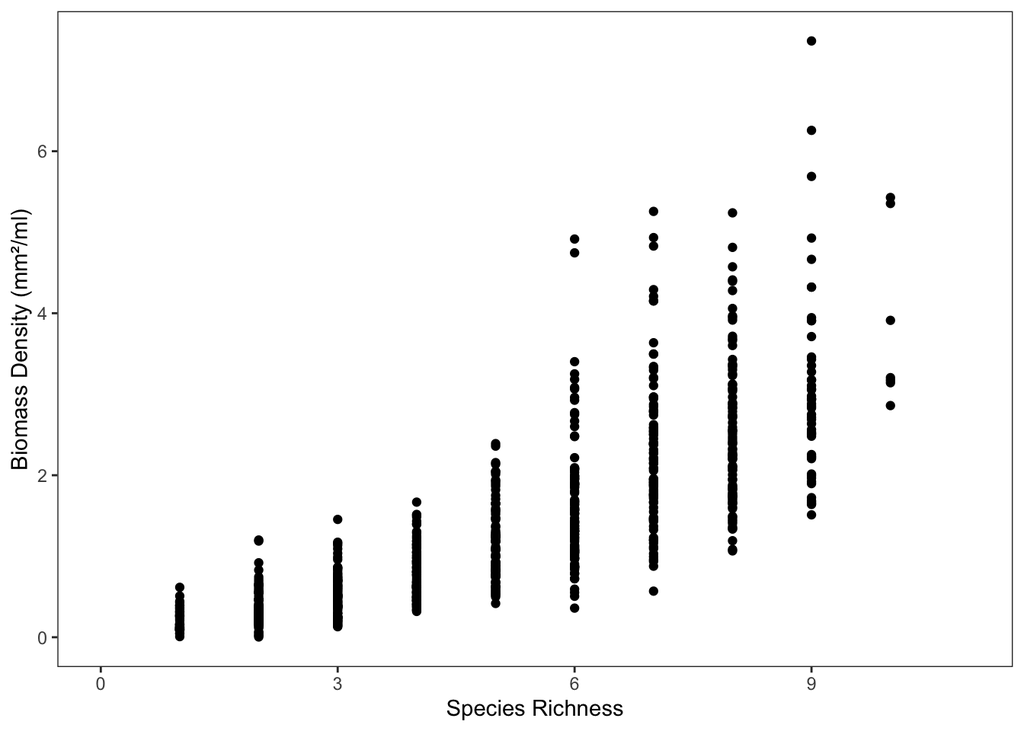

```r
ds_ecosystems %>%
  filter(trophic_type == "heterotrophic") %>%
  ggplot(aes(x = species_richness,
             y = bioarea_mm2_per_ml)) +
  geom_point() +
  xlim(0, length(protist_species)) +
  labs(x = axis_names$axis_name[axis_names$variable == "species_richness"],
       y = axis_names$axis_name[axis_names$variable == "bioarea_mm2_per_ml"]) +
  theme_bw() +
    theme(panel.grid.major = element_blank(),
          panel.grid.minor = element_blank(),
          legend.position = legend_position,
          legend.key.width = unit(legend_width_cm, "cm"))
```

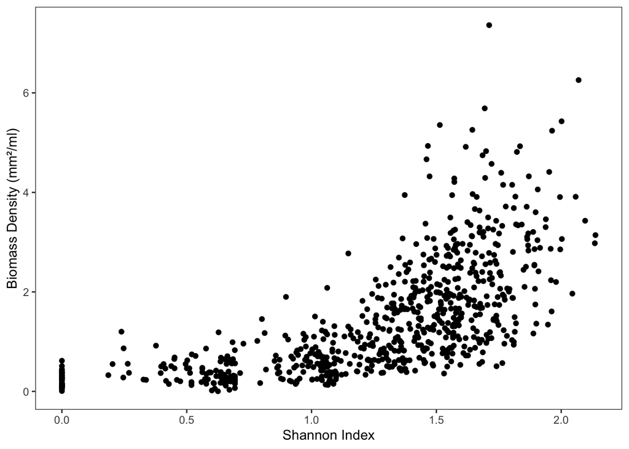

```r
ds_ecosystems %>%
  filter(trophic_type == "heterotrophic") %>%
  ggplot(aes(x = shannon,
             y = bioarea_mm2_per_ml)) +
  geom_point() +
  labs(x = axis_names$axis_name[axis_names$variable == "shannon"],
       y = axis_names$axis_name[axis_names$variable == "bioarea_mm2_per_ml"]) +
  theme_bw() +
    theme(panel.grid.major = element_blank(),
          panel.grid.minor = element_blank(),
          legend.position = legend_position,
          legend.key.width = unit(legend_width_cm, "cm"))
```

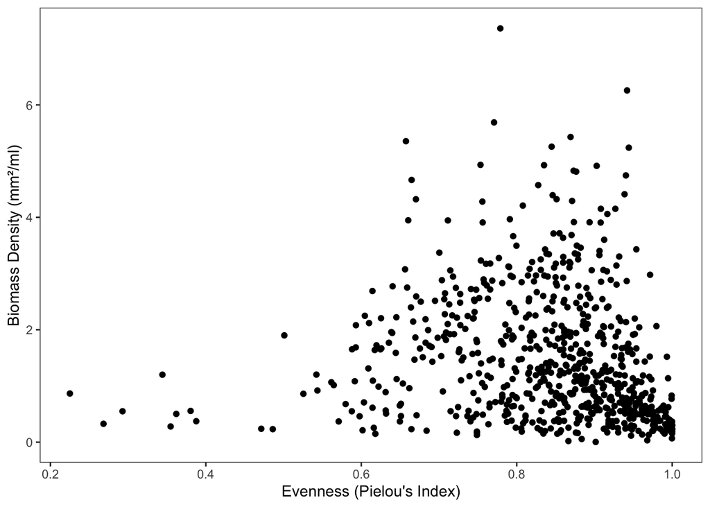

```r
ds_ecosystems %>%
  filter(trophic_type == "heterotrophic",
         is.na(evenness_pielou) != TRUE) %>%
  ggplot(aes(x = evenness_pielou,
             y = bioarea_mm2_per_ml)) +
  geom_point() +
  labs(x = axis_names$axis_name[axis_names$variable == "evenness_pielou"],
       y = axis_names$axis_name[axis_names$variable == "bioarea_mm2_per_ml"]) +
  theme_bw() +
    theme(panel.grid.major = element_blank(),
          panel.grid.minor = element_blank(),
          legend.position = legend_position,
          legend.key.width = unit(legend_width_cm, "cm"))
```

## Paper

When we study the autotrophic-heterotrophic spatial feedback we always consider the size of the ecosystems to be the same. In my past experiment I show that the size of the ecosystems matter. However, we only showed that the relative size of ecosystems had an effect. Here, I ran an experiment in which I show that the absolute size of ecosystems matters as well. To do so, I run an experiment.

## Other

### Running time

```r
end_time = Sys.time()
round(end_time - start_time, digits = 1)
```

```
## Time difference of 2.3 mins
```

### Useful code

If you want to change a certain part of the code using the following code in Unix:

```r
#Rmd script
cd /Users/ema/Documents/GitHub/RelativeSize/r_files
sed -i '' 's/old_string/new_string/g' *.Rmd

#R script
cd /Users/ema/Documents/GitHub/RelativeSize/r_files/functions
sed -i '' 's/old_string/new_string/g' *.R
```

If you want to share a dataset and get a reproducible object, use the following R code:

```r
dput()
```

If you want to create a hidden section:

```r
<details>
<summary>Click here to .../summary>
</details>
```

Save files to calculate the effect size of meta-ecosystems.

```r
write.csv(combination_sets_isolated_systems,
          file = here("files_for_ds_metaecos_es", "combination_sets_isolated_systems.csv"))

write.csv(ds_metaecosystems,
          file = here("files_for_ds_metaecos_es", "ds_metaecosystems.csv"))

write.csv(ds_metaecosystems,
          file = here("files_for_ds_metaecos_es", "ds_metaecosystems.csv"))
```

## Bibliography

Borenstein, Michael, Larry V. Hedges, Julian P. T. Higgins, and Hannah Rothstein. 2009. *Introduction to Meta-Analysis*. John Wiley & Sons.

Hedges, Larry V., and Ingram Olkin. 1985. *Statistical Methods for Meta-Analysis*. Elsevier. https://doi.org/10.1016/C2009-0-03396-0.

Rosenberg, Michael S., Hannah R. Rothstein, and Jessica Gurevitch. 2013. “Effect Sizes: Conventional Choices and Calculations.” In *Handbook of Meta-Analysis in Ecology and Evolution*, 61–71. https://doi.org/10.23943/princeton/9780691137285.003.0006.